# Mary Holtam Final

Mary Holtam

2025-06-08

Link to GitHub repository: https://github.com/meholtam/ENVS-193DS_spring-2025_final.git

# Initial set up:

```r
#making sure no messages show when loading in packages
library(tidyverse) # loading in Tidyverse package
library(here) # loading in here package
library(gt) # loading in gt package
library(ggplot2) # loading in ggplot2 package
library(readxl) # loading in readxl package
library(dplyr) # loading in dplyr package
library(DHARMa) # loading in DHARMa package
library(lubridate) # loading in lubridate package
library(MuMIn) # loading in MuMIn package
library(ggeffects) # loading in ggeffects package
library(janitor) # loading in janitor package
sst <- read_csv("~/Desktop/ENVS-193DS/ENVS-193DS_spring-2025_final/data/sst.csv") # reading in sea surface temperature data
nest_boxes <- read_csv("~/Desktop/ENVS-193DS/ENVS-193DS_spring-2025_final/data/occdist.csv") # reading in nest box data
```

ˆ # Problem 1: Research Writing

## a) Transparent statistical methods

In part 1, my coworker used a Pearson correlation test. Because the results section details that the correlation between distance from head water and annual total nitrogen load was being measured, we know that a correlation test was being used. In part 2, the coworker used a one-way ANOVA test. Here, the average nitrogen load was measured across sources, including urban land, atmospheric deposition, fertilizer, wastewater treatment, and grasslands, which points to the use of an ANOVA test which looks at means across variables from unrelated groups.

## b) More information needed

A piece of information from the ANOVA test that would provide greater context for the results would be the effect size. This would help demonstrate what proportion of variance in nitrogen load each source type provides. A second helpful piece of information would be the group mean for each source, which would provide the average nitrogen load that each source contributes. This would allow readers to understand which sources, from urban land to grasslands, cause the greatest amount of pollution.

## c) Suggestions for rewriting

Statement 1- We found that total nitrogen load (kg year-1) increased as distance from the headwater (km) decreased, suggesting that upstream locations supply more nitrogen input. (Correlation test: r= correlation coefficient, p= 0.03, α = significance level, n= sample size).

Statement 2- Each source measured contributed a different average nitrogen load (kg year-1), with urban land, fertilizer, and wastewater treatment contributing significantly more nitrogen than atmospheric deposition and grassland sources. (One-Way ANOVA: F(df1, df2) = F-statistic, p = 0.02, α = [significance level], distribution = F-distribution, n= sample size).

# Problem 2: Data Visualization

## a. Cleaning and summarizing

```r
sst_clean <- sst |>  # cleaning sst data
  mutate(
    year = factor(year(date), levels = c("2018", "2019", "2020", "2021", "2022", "2023")),  # comma after year(date)
    month = month(date, label = TRUE, abbr = TRUE)  # comma was missing, but this is last argument so no comma needed here
  ) |>
  filter(year %in% c("2018", "2019", "2020", "2021", "2022", "2023")) |>  # filter years of interest
  group_by(year, month) |>  # groups data by year and month
  summarize(mean_monthly_sst = round(mean(temp, na.rm = TRUE), 1), .groups = "drop")  # calculates mean SST per month

sst_clean |> slice_sample(n = 5) # randomly selects 5 rows from data frame
```

```
## # A tibble: 5 × 3
##   year  month mean_monthly_sst
##   <fct> <ord>            <dbl>
## 1 2022  Nov               15
## 2 2022  Aug               17.5
## 3 2020  Jun               15.9
## 4 2020  Sep               18.7
## 5 2021  Jun               15.9
```

```r
str(sst_clean) # displays structure of sst_clean object
```

```
## tibble [72 × 3] (S3: tbl_df/tbl/data.frame)
##  $ year            : Factor w/ 6 levels "2018","2019",..: 1 1 1 1 1 1 1 1 1 1 ...
##  $ month           : Ord.factor w/ 12 levels "Jan"<"Feb"<"Mar"<..: 1 2 3 4 5 6 7 8 9 10 ...
##  $ mean_monthly_sst: num [1:72] 15 14.3 13.5 12.8 13.6 15.5 18.2 19.6 18.2 18.5 ...
```

## b. Visualize the data

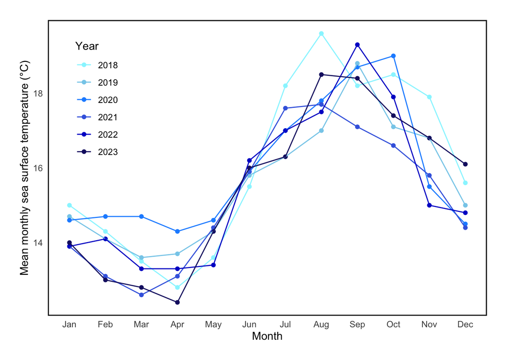

```r
ggplot(data = sst_clean, # sets the data frame
       aes(x = month, # the x-axis should be date
           y = mean_monthly_sst, # the y-axis should be total_rain
           color = year, # color all geometries by water_year
           group = year)) + # tell ggplot how to group the data for the lines
  geom_point() + # adding points
  geom_line() + # adding lines
  scale_color_manual(values = c(
    "2018" = "cadetblue1",
    "2019" = "skyblue",
    "2020" = "dodgerblue",
    "2021" = "royalblue",
    "2022" ="mediumblue",
    "2023" = "midnightblue"
  )) + #changing the colors of each line to a blue gradient
 theme(
   panel.background = element_blank(), # Makes the panel background transparent/blank
   panel.border = element_rect(color = "black", fill = NA, linewidth = 1), # add black border
    axis.line = element_blank(), # Removes both x and y axis lines
    plot.margin = margin(20, 20, 20, 20), # make it so graph does not get cut off
    axis.ticks = element_blank(), # Removes all axis ticks
    legend.position = c(0.05, 0.95), # move legend to the top left
    legend.justification = c(0, 1), # move legend to top left
    coord_cartesian(clip = "off") # prevent legend from being cut off
  ) +
  labs(x = "Month", # relabeling the x-axis
       y = "Mean monthly sea surface temperature (°C)", # relabeling the y-axis
       color = "Year") # relabeling the legend
```

# Problem 3: Data Analysis

## a) Response variable

In this data set, the 1s and 0s refer to whether a certain species is occupying the box, or if there is a different species/if the box is empty. The 1 in the sp column refers to the presence of a swift parrot and the 0 refers to it being occupied by a different species or being empty; the 1 in ths cs column refers to the common starling and the 0 refers to it being occupied by a different species or being empty; the 1 in the e column refers to it being unoccupied or empty and the 0 refers to it being occupied; and the 1 in the tm column refers to it being occupied by the tree martin and the 0 refers to another species.

## b) Purpose of study

The target species for the nest boxes being studied in this paper is the swift parrot, where the common starling and the tree martin are non-target species that may be occupying the nest boxes. The common starling and tree martin are competitors of the swift parrot for this habitat and are the main beneficiaries of the boxes, so this study seeks to identify what factors cause greater occupancy of these competitors over the intended beneficiary, the swift parrot.

## c) Difference in “seasons”

The two years that are referred to as seasons are 2016 and 2019. The main difference between these years in the context of this study is that in 2016 the boxes were newly deployed where in 2019 they had been established and present for three years.

## d) Table of models

| Model number | Season | Distance to forest edge | Model Description |
| --- | --- | --- | --- |
| 0 | No | No | no predictors(null model) |
| 1 | Yes | Yes | all predictors(saturdated model) |
| 2 | Yes | No | GLM:Predictor variable=season |
| 3 | No | Yes | GLM:Predictor variable=distance to forest edge |

## e) Run the models

```r
nest_boxes_clean <- nest_boxes |>
  clean_names() # cleaning data
```

```r
# model 0: null model
model0 <- glm( #using GLM
  sp ~ 1, # formula, null so using no predictor
  data = nest_boxes_clean, # data frame
  family = binomial # tells R that response variable is binary
)

# model 1: all predictors/saturated
model1 <- glm(
  sp ~ season * edge_distance, # formula using season and edge distance as predictors
  data = nest_boxes_clean, # data frame
  family = binomial # tells R that response variable is binary
)

# model 2: season
model2 <- glm(
  sp ~ season, # formula using season as predictor
  data = nest_boxes_clean, #data frame
  family = binomial # tells R that response variable is binary
)

# model 3: distance to forest edge
model3 <- glm(
  sp ~ edge_distance, # formula using edge distance as predictor
  data = nest_boxes_clean, #data frame
  family = binomial # tells R that response variable is binary
)
```

## f) Check the diagnostics

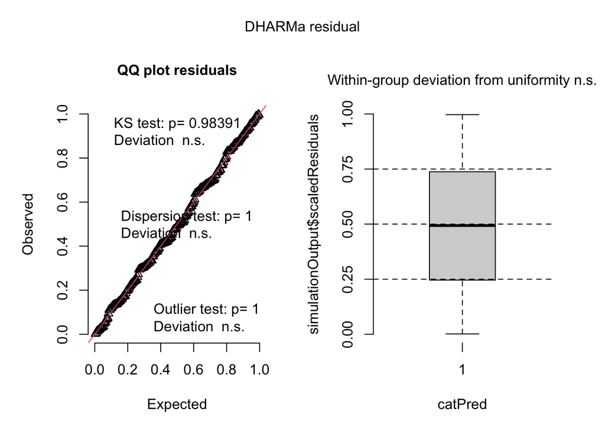

```r
#model 0 diagnostics:
res0 <- simulateResiduals(model0) # simulate residuals for model 0
plot(res0) # stores simulated residuals in object called res0
```

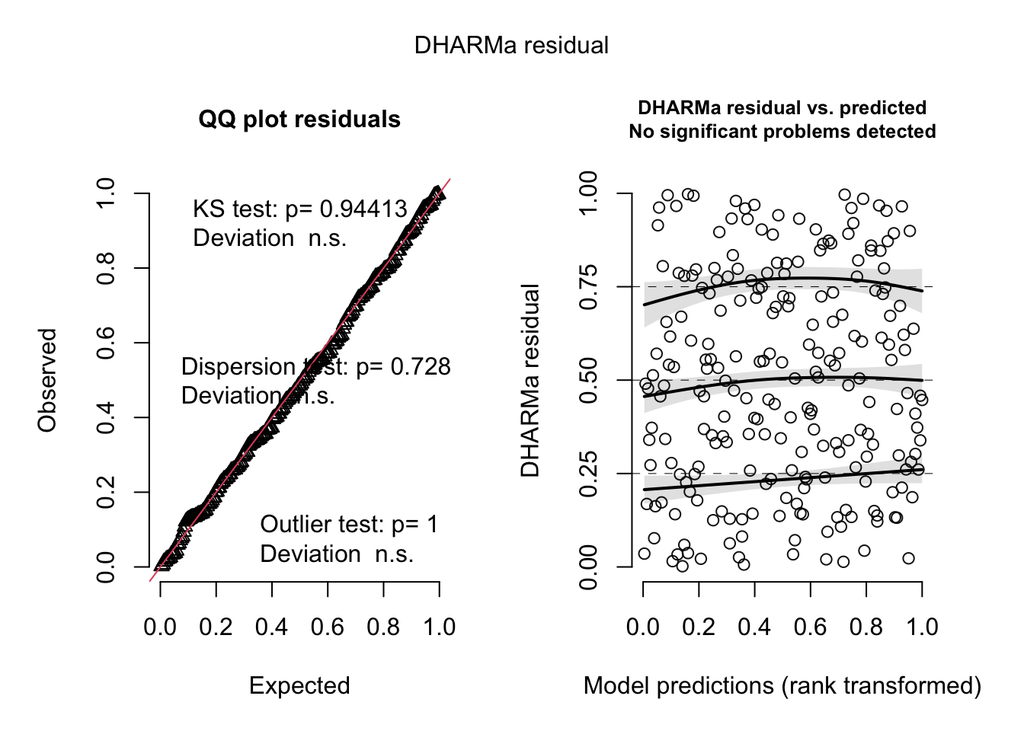

```r
#model 1 diagnostics
res1 <- simulateResiduals(model1) # simulate residuals for model 1
plot(res1) # stores simulated residuals in object called res1
```

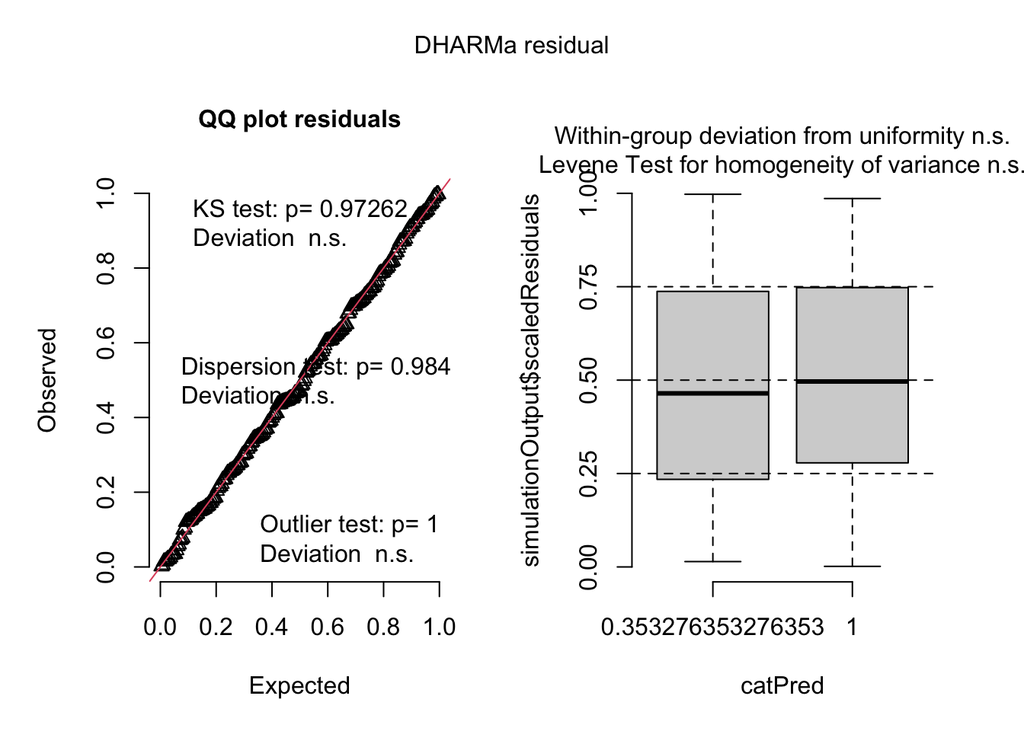

```r
#model 2 diagnostics
res2 <- simulateResiduals(model2) # simulate residuals for model 2
plot(res2) # stores simulated residuals in object called res2
```

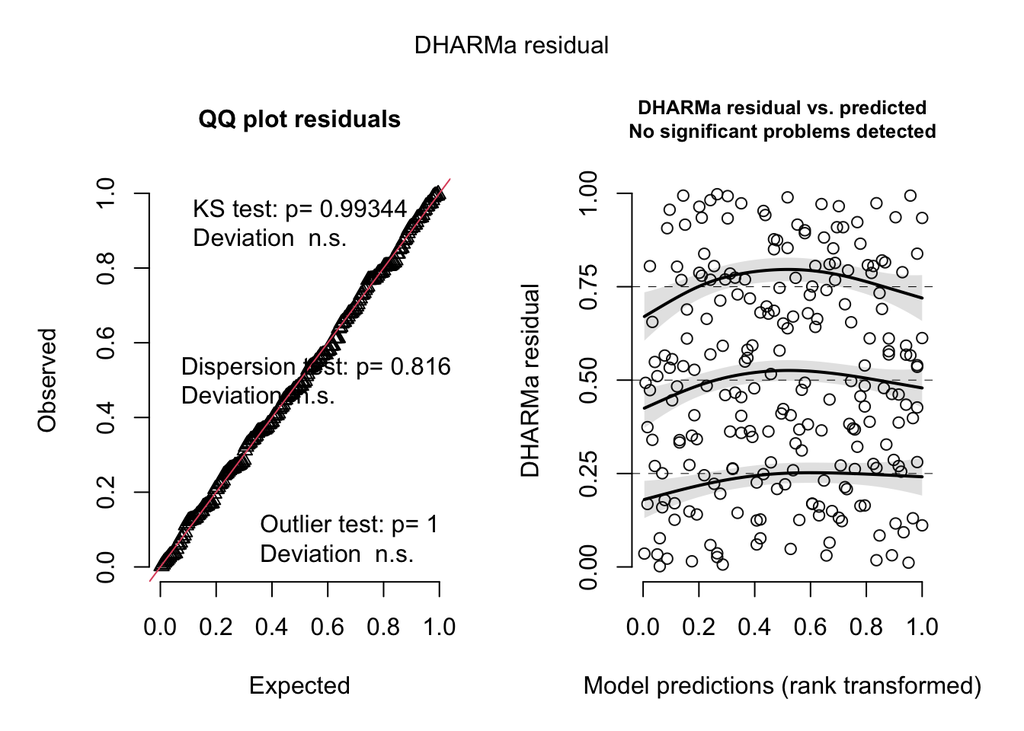

```r
#model 3 diagnostics
res3 <- simulateResiduals(model3) # simulate residuals for model 3
plot(res3) # stores simulated residuals in object called res3
```

## g) Select the best model

The best model can be described by the Akaike’s Information Crierion, or AIC. Looking at this, the best model would be Model 1, which looks at edge distance and season as predictors, as the AIC is 227.0325. The response variable for Model 1 is occupancy of the swift parrot. Therefore, looking at both edge distance and season is the best way to determine the occupancy of the swift parrot in the nest boxes.

```r
AICc(model1, #using AIC to run model selection
     model2,
     model3,
     model0)|>
  # arranging output in descending order of AIC
  arrange(AICc)
```

```
##        df     AICc
## model1  4 227.0325
## model3  2 229.6716
## model2  2 236.3744
## model0  1 238.8318
```

## h) Visualize the model predictions

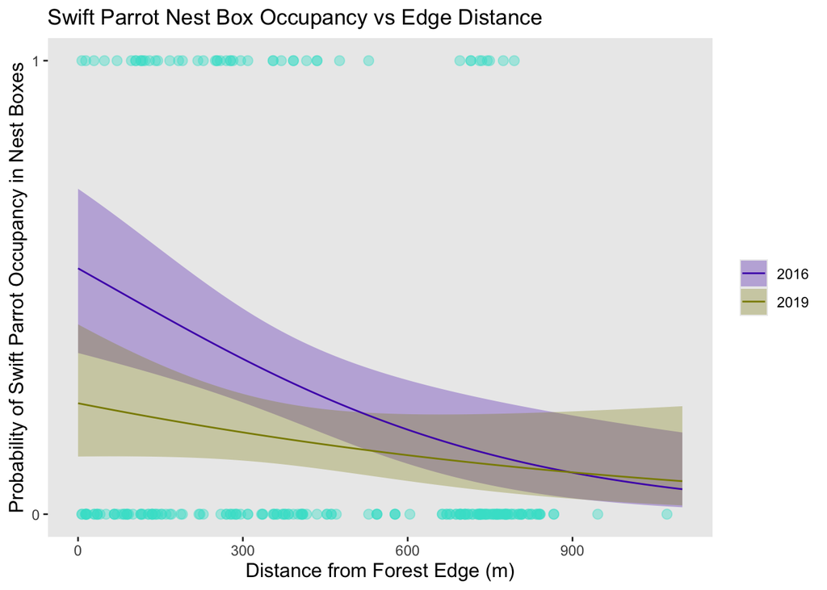

```r
#make predictions using ggpredict for both predictions and their interactions
mod_preds <- ggpredict(model1, terms = c("edge_distance [0:1100 by=10]", "season"))

ggplot(nest_boxes_clean, # creates base ggplot object using clean data
       aes(x = edge_distance, #x acis is edge distance
           y = sp )) + #y axis is sp occupancy
  geom_point(size = 2.5, # makes points larger than default
             alpha = 0.4, # makes points semi-transparent
             color = "#40E0D0") + # making point color turquoise
  geom_ribbon(data = mod_preds, # adds confidence ribbon using model prediction data
              aes(x = x,
              ymin = conf.low, # confidence interval low boundary
              ymax = conf.high, # confidence interval high boundary
              y = predicted,
              fill = group),
              inherit.aes = FALSE, # adds prediction line
              alpha = 0.3) +
    labs(title = "Swift Parrot Nest Box Occupancy vs Edge Distance") +
geom_line(data = mod_preds,
          aes(x = x,
              y = predicted,
              color = group)) +
  scale_y_continuous(name = "Probability of Swift Parrot Occupancy in Nest Boxes", # naming y-axis label in full
    limits = c(0,1), breaks = c(0,1)) + # only shows tick marks at 0 and 1
  scale_x_continuous(name = "Distance from Forest Edge (m)") + # adding x axis label in full
  scale_fill_manual(values = c("2016" = "#5008B8", "2019" = "#8B8B00")) + # manually changing fill color
scale_color_manual(values = c("2016" = "#5008B8", "2019" = "#8B8B00"))+ # manually changing line color
theme(
  panel.grid = element_blank(), # remove all grid lines
  axis.title = element_text(size = 12), # make axis labels more clear
  legend.title = element_blank(), # make legend more clear
  legend.position = "right" # move legend to the right
)
```

## j) Calculate model predictions

```r
predictions <- ggpredict(model1, #the predictions function saves the output for later use
          terms = c("edge_distance [0,900]", "season"))
print(predictions)
```

```
## # Predicted probabilities of sp
##
## season: 2016
##
## edge_distance | Predicted |     95% CI
## --------------------------------------
##             0 |      0.54 | 0.36, 0.72
##           900 |      0.09 | 0.04, 0.22
##
## season: 2019
##
## edge_distance | Predicted |     95% CI
## --------------------------------------
##             0 |      0.24 | 0.13, 0.42
##           900 |      0.09 | 0.03, 0.23
```

## k) Interpret your results

# Problem 4: Affective and exploratory visualizations

## a) Comparing visualizations

In both Homework 2 and 3, I created visualizations to represent my personal data. In Homework 2, these consisted of exploratory visualizations, such as a box plot. Homework 3 focused on creating affective visualizations, such as the calendar I created representing my mean daily step count. These visualizations are different from each other in the way I represented my data as the box plot has a much more statistical approach, making distribution factors like spread and variation very clear for viewers. In order to understand the main point of this plot, viewers must have some prior knowledge about statistical plots and be able to interpret a box plot. On the other hand, my calendar only shows daily step count and anyone would be able to understand the point that the visualization is trying to make, even if they do not have knowledge of data science and plots. In both visualizations, the mean daily step count is represented and it is clear in both which day had the greatest amount of steps. The data is a bit different in my Homework 2 plots due to the fact that I did not have all of my data yet. However, in both the means are clear and the relationship between day of the week and mean step count is emphasized. The only reason the trend of which day has the greatest mean number of steps is different between visualizations is due to the difference in amount of data that was collected between Homeworks 2 and 3. The feedback I got from instructors was to improve my y-axis and geometry of my box plot, which I fixed and I believe having more data made the plot more clear and easy to understand.